# TP3: Spatial model structure

About Besag and GPs

Author

Lionel Hertzog

Published

April 7, 2026

```r
library(sf)
library(INLA)
library(inlabru)
library(tidyverse)
library(patchwork)
library(DHARMa)
```

**NoteObjective**

For this TP we will use two datasets, the first one is the total number of covid cases per department between may 2020 and march 2021 for areal based modelling and the seconde one is the total number of plant species observed on forest inventory plots in the Vosges biogeographical regions for continuous models.

The aim is to build model with spatial structure, checking the estimated spatial fields and the effects of additionnal covariates.

## 1 First part - areal data

First let’s read and look at the data:

```r
covid <- st_read("covid_dep.gpkg", quiet = TRUE)

summary(covid)
```

```
     dep            semaine_glissante    population         positive
 Length:96          Length:96          Min.   :  76286   Min.   :   3.00
 Class :character   Class :character   1st Qu.: 291893   1st Qu.:  75.75
 Mode  :character   Mode  :character   Median : 536168   Median : 174.50
                                       Mean   : 676020   Mean   : 481.72
                                       3rd Qu.: 847942   3rd Qu.: 465.75
                                       Max.   :2588988   Max.   :4334.00
     tested                 geom
 Min.   :  931   MULTIPOLYGON :96
 1st Qu.: 3856   epsg:4326    : 0
 Median : 6324   +proj=long...: 0
 Mean   :11008
 3rd Qu.:12692
 Max.   :69157
```

```r
str(covid)
```

```
Classes 'sf' and 'data.frame':  96 obs. of  6 variables:
 $ dep              : chr  "01" "02" "03" "04" ...
 $ semaine_glissante: chr  "2020-08-28-2020-09-03" "2020-08-28-2020-09-03" "2020-08-28-2020-09-03" "2020-08-28-2020-09-03" ...
 $ population       : int  656955 526050 331315 165197 141756 1079396 326875 265531 152398 309907 ...
 $ positive         : int  429 115 76 72 42 1401 105 49 58 86 ...
 $ tested           : int  8407 3620 4711 3099 1504 26465 3426 4033 2082 4383 ...
 $ geom             :sfc_MULTIPOLYGON of length 96; first list element: List of 1
  ..$ :List of 1
  .. ..$ : num [1:389, 1:2] 5.62 5.61 5.6 5.6 5.58 ...
  ..- attr(*, "class")= chr [1:3] "XY" "MULTIPOLYGON" "sfg"
 - attr(*, "sf_column")= chr "geom"
 - attr(*, "agr")= Factor w/ 3 levels "constant","aggregate",..: NA NA NA NA NA
  ..- attr(*, "names")= chr [1:5] "dep" "semaine_glissante" "population" "positive" ...
```

The columns are:

- dep: an indicator for the department
- semaine_glissante: the week of measurement
- population: the number of inhabitant
- positive: the number of positive test cases
- tested: the number of effectuated tests
- geom: the sf shapefile

### 1.1 Data Exploration

Make maps of population, positive cases, tested and positive rate (positive / tested). Do you see some patterns emerging?

**TipAnswer**

Here’s how to do it in ggplot:

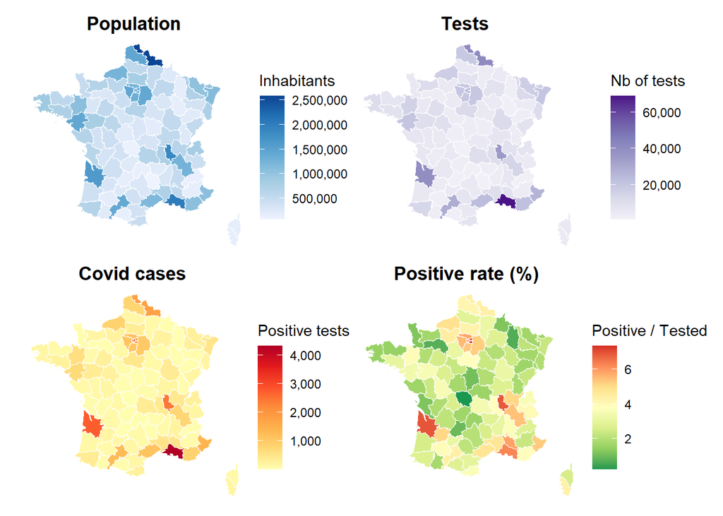

```r
covid$p_rate <- with(covid, (positive / tested) * 100)

# Helper function
make_map <- function(data, variable, title, label,
                     palette = "YlOrRd", direction = 1) {
  ggplot(data) +
    geom_sf(aes(fill = .data[[variable]]), colour = "white", linewidth = 0.2) +
    scale_fill_distiller(
      palette   = palette,
      direction = direction,
      name      = label,
      labels    = scales::label_comma()
    ) +
    labs(title = title) +
    theme_void() +
    theme(
      plot.title      = element_text(size = 13, face = "bold", hjust = 0.5)
    )
}

# Build four maps
p_pop <- make_map(covid, "population",
                  "Population",
                  "Inhabitants",
                  palette = "Blues")

p_pos <- make_map(covid, "positive",
                  "Covid cases",
                  "Positive tests",
                  palette = "YlOrRd")

p_tes <- make_map(covid, "tested",
                   "Tests",
                   "Nb of tests",
                   palette = "Purples")

p_rat <- make_map(covid, "p_rate",
                   "Positive rate (%)",
                   "Positive / Tested",
                   palette = "RdYlGn",
                   direction = -1)        # red = high rate (bad)

# Combine the plots
combined <- (p_pop + p_tes) / (p_pos + p_rat)

combined
```

## 2 Model fitting - BYM2

### 2.1

Fit a BYM2 model to the covid department data. The response variable is the number of positive test cases, since the testing intensity varies per department we will use an *offset* to account for this. A Poisson model can then be written as:

$$positive_i \sim Poisson(\lambda_i)$$

$$log(\frac{\lambda_i}{tested_i}) = \beta_0 + f(department_i)$$
This can be directly included into the inlabru formula as `offset(log(tested))`.

Before fitting the model, you will need to create the dependency graph between the department using `spdep::poly2nb` to create the graph and `spdep::nb2mat(..., style = "B")` to turn this into a matrix than INLA understands. Also remember that you need to pass the department ID as integer to the INLA model formula.

**TipHint - build the dependency matrix**

```r
## first make the graph
neigh <- spdep::poly2nb(...)

## then turn this into a matrix
W.dep <- nb2mat(..., style = "B")
```

**TipAnswer - build the dependency matrix**

```r
## first make the graph
neigh <- spdep::poly2nb(covid)

## then turn this into a matrix
W.dep <- spdep::nb2mat(neigh, style = "B", zero.policy = TRUE)
```

**TipHint - model fitting**

```r
covid$id <- ...
m_dep <- bru(positive ~ ..., data = covid, family = "poisson")
```

**TipAnswer - model fitting**

```r
covid$id <- as.integer(factor(covid$dep))
m_dep <- bru(positive ~ Intercept(1) + offset(log(tested)) + bym2_field(id, model = "bym2", graph = W.dep), data = covid, family = "poisson")
summary(m_dep)
```

```
inlabru version: 2.13.0
INLA version: 25.06.07
Components:
Intercept: main = linear(1), group = exchangeable(1L), replicate = iid(1L), NULL
bym2_field: main = bym2(id), group = exchangeable(1L), replicate = iid(1L), NULL
offset: main = const(log(tested)), group = exchangeable(1L), replicate = iid(1L), NULL
Observation models:
  Family: 'poisson'
    Tag: <No tag>
    Data class: 'sf', 'data.frame'
    Response class: 'integer'
    Predictor: positive ~ .
    Additive/Linear: TRUE/TRUE
    Used components: effects[Intercept, bym2_field, offset], latent[]
Time used:
    Pre = 18.4, Running = 0.383, Post = 0.357, Total = 19.1
Fixed effects:
            mean    sd 0.025quant 0.5quant 0.975quant   mode kld
Intercept -3.564 0.024     -3.614   -3.564     -3.516 -3.564   0

Random effects:
  Name    Model
    bym2_field BYM2 model

Model hyperparameters:
                          mean    sd 0.025quant 0.5quant 0.975quant  mode
Precision for bym2_field 3.734 0.690      2.535    3.681      5.240 3.590
Phi for bym2_field       0.824 0.128      0.496    0.856      0.979 0.934

Marginal log-Likelihood:  -521.15
 is computed
Posterior summaries for the linear predictor and the fitted values are computed
(Posterior marginals needs also 'control.compute=list(return.marginals.predictor=TRUE)')
```

What do you think of the fitted model? How much of the spatial variation is structured by the neighborhood between the department?

**TipBonus question**

Add explicit PC priors on the hyperparameters of the BYM2 component.

## 3 Model checks - BYM2

Generate simulations from the fitted model to check the residuals using DHARMa. Note, the number of test case (the offset) should be passed to the linear predictor as `log(tested)`.

**TipAnswer**

Here is how this can be done:

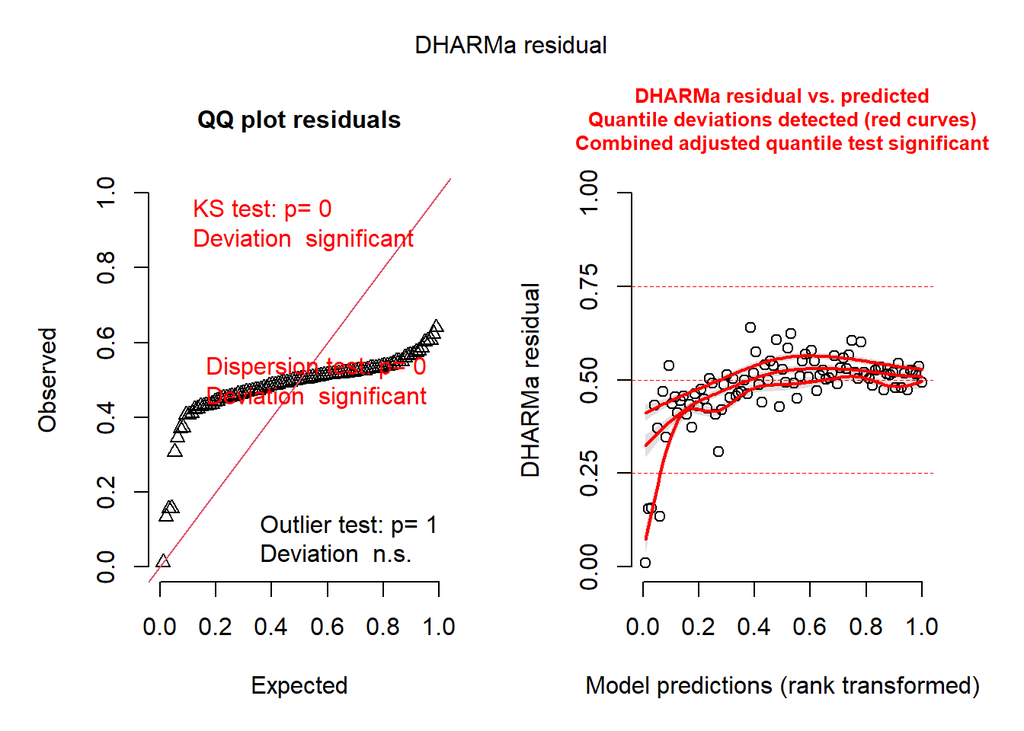

```r
sims <- generate(
  m_dep,
  covid,
  ~ rpois(n = nrow(covid),
          lambda = exp(Intercept + bym2_field + log(tested))),
  n.samples = 250
)

ch_mdep <- createDHARMa(
  simulatedResponse  = sims,
  observedResponse   = covid$positive,
  fittedPredictedResponse = predict(m_dep, covid,
                                    ~ exp(Intercept + bym2_field + log(tested)))$mean
)

plot(ch_mdep)
```

What is your take on these residual distributions? How would you improve the model if needed? Also check the relation between the predicted number of positive cases and the observed values.

### 3.1 Model plots

Now make a map of the predicted positive rate per department and the standard deviation of the prediction. Remember that we used a log link to fit the regression.

**TipAnswer**

Here is how this can be done:

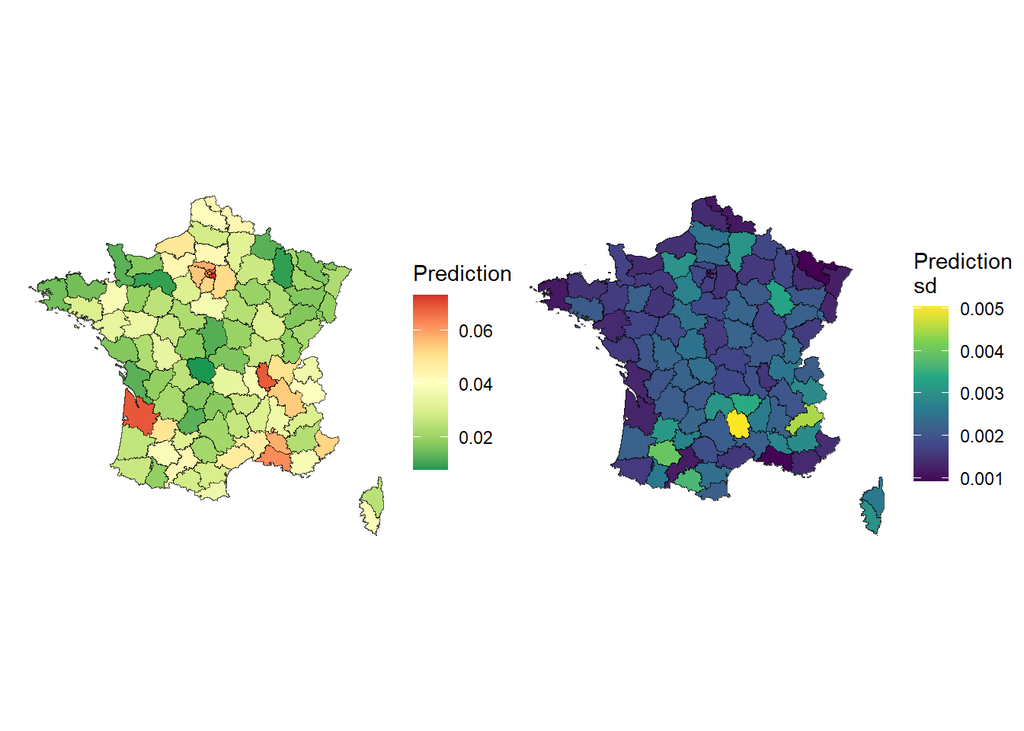

```r
pred_dep <-  predict(m_dep, covid,  ~ exp(Intercept + bym2_field))

p_pred <- ggplot(pred_dep) +
  geom_sf(aes(fill = mean)) +
  scale_fill_distiller(palette = "RdYlGn",
                       direction = -1,
                       name = "Prediction") +
  theme_void()

p_pred_sd <- ggplot(pred_dep) +
  geom_sf(aes(fill = sd)) +
  scale_fill_continuous(type = "viridis",
                        name = "Prediction\nsd") +
  theme_void()

p_pred | p_pred_sd
```

### 3.2

Bonus:

Create a new model with an additionnal covariate: the population density in the department [note the area of the department is available via `st_area(covid)`]. What is the effect of population density on the positive rate of covid tests ? Compare the estimated spatial hyperparameters between the models with and without the population density.

## 4 Continuous spatial field - botanical diversity

In this second part we will model a continuous spatial field on a dataset of botanical diversity.

First we load and explore the data:

```r
spdiv <- st_read("plant_rich.gpkg")
summary(spdiv)
```

```
     npp                  zp               n                    geom
 Length:5339        Min.   : 163.0   Min.   : 1.00   POINT        :5339
 Class :character   1st Qu.: 347.0   1st Qu.:12.00   epsg:27572   :   0
 Mode  :character   Median : 459.0   Median :18.00   +proj=lcc ...:   0
                    Mean   : 517.4   Mean   :20.45
                    3rd Qu.: 652.0   3rd Qu.:26.00
                    Max.   :1290.0   Max.   :96.00
```

```r
str(spdiv)
```

```
Classes 'sf' and 'data.frame':  5339 obs. of  4 variables:
 $ npp : chr  "14-54-264-1-052T" "14-88-249-1-075T" "14-88-251-1-071T" "14-88-251-1-073T" ...
 $ zp  : int  443 249 334 369 332 336 297 318 585 633 ...
 $ n   : num  14 28 25 21 19 21 47 23 12 19 ...
 $ geom:sfc_POINT of length 5339; first list element:  'XY' num  940167 2397986
 - attr(*, "sf_column")= chr "geom"
 - attr(*, "agr")= Factor w/ 3 levels "constant","aggregate",..: NA NA NA
  ..- attr(*, "names")= chr [1:3] "npp" "zp" "n"
```

### 4.1 Model building

#### 4.1.1

We now want to fit a model to this dataset with a continuous spatial field. We will use a Matern covariance function to model this field and a SPDE approach for fast computation.

To fit this model in inlabru, we first need to set the mesh (see the function `fmesher::fm_mesh_2D_inla`) and create an associated SPDE (see the function `INLA::inla.spde2.pcmatern`).

**TipHint**

```r
library(fmesher)
## set up the mesh
m_d <- fm_mesh_2d_inla(loc = ...,
                       max.edge = ...,
                       max.n.strict = 1e4)

## set up spde
spde_field <- inla.spde2.pcmatern(mesh = ...,
                                  prior.range = ...,
                                  prior.sigma = ...)
```

**TipAnswer**

```r
library(fmesher)
## set up the mesh
m_d <- fm_mesh_2d_inla(loc = st_coordinates(spdiv),
                       max.edge = c(100, 1e4),
                       max.n.strict = 1e4)

## set up spde
spde_field <- inla.spde2.pcmatern(mesh = m_d,
                                  prior.range = c(10000, 0.05),
                                  prior.sigma = c(0.6, 0.01))
```

#### 4.1.2

Now we can set a model, we will first use this structure:

$$diversity_i \sim Poisson(\lambda_i)$$

$$log(\lambda_i) = \beta_0 + s_i$$

$$s_i \sim MVN(0, \Sigma)$$
$$\Sigma = Matern(d(s_i, s_j), \sigma, \rho)$$

Fit such a model using inlabru, note that we pass the column of the point coordinates as ID for the spatial field.

**TipHint**

```r
m_div <- bru(n ~ ... + ..., data = spdiv, family = "poisson")
```

**TipAnswer**

```r
m_div <- bru(n ~ Intercept(1) + matern_field(geom, model = spde_field), data = spdiv, family = "poisson")
summary(m_div)
```

```
inlabru version: 2.13.0
INLA version: 25.06.07
Components:
Intercept: main = linear(1), group = exchangeable(1L), replicate = iid(1L), NULL
matern_field: main = spde(geom), group = exchangeable(1L), replicate = iid(1L), NULL
Observation models:
  Family: 'poisson'
    Tag: <No tag>
    Data class: 'sf', 'data.frame'
    Response class: 'numeric'
    Predictor: n ~ .
    Additive/Linear: TRUE/TRUE
    Used components: effects[Intercept, matern_field], latent[]
Time used:
    Pre = 1.28, Running = 33.1, Post = 2.36, Total = 36.7
Fixed effects:
           mean   sd 0.025quant 0.5quant 0.975quant  mode kld
Intercept 2.914 0.01      2.895    2.914      2.934 2.914   0

Random effects:
  Name    Model
    matern_field SPDE2 model

Model hyperparameters:
                           mean    sd 0.025quant 0.5quant 0.975quant     mode
Range for matern_field 1049.566 34.51    982.943 1049.108   1118.811 1048.431
Stdev for matern_field    0.596  0.01      0.577    0.596      0.616    0.596

Marginal log-Likelihood:  -19933.12
 is computed
Posterior summaries for the linear predictor and the fitted values are computed
(Posterior marginals needs also 'control.compute=list(return.marginals.predictor=TRUE)')
```

#### 4.1.3

Check the model assumptions using DHARMa, first generating simulated posterior samples using `generate`.

**TipAnswer**

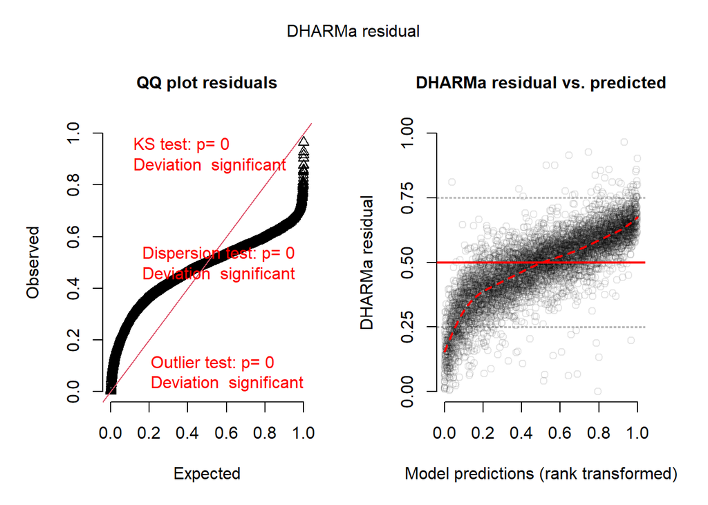

```r
sims <- generate(
  m_div,
  spdiv,
  ~ rpois(n = nrow(spdiv),
          lambda = exp(Intercept + matern_field)),
  n.samples = 250
)

ch_mdiv <- createDHARMa(
  simulatedResponse  = sims,
  observedResponse   = spdiv$n,
  fittedPredictedResponse = predict(m_div, spdiv,
                                    ~ exp(Intercept + matern_field))$mean
)

plot(ch_mdiv)
```

What do you think? How would you improve this model?

#### 4.1.4

Now we can plot the fitted spatial field using `predict`. For this we need a grid, we can use the following grid: `grid_poly.gpkg`. Note that for the predict call we need to give in points so we can use the centroids of these grid polygons saved in `grid_xy.gpkg`.

**TipHint**

```r
grid_poly <- st_read(...)
grid_xy <- st_read(...)

pred <- predict(...)

pred_grid <- st_drop_geometry(...)
pred_grid <- st_as_sf(...)

ggplot() +
  ...
```

**TipAnswer**

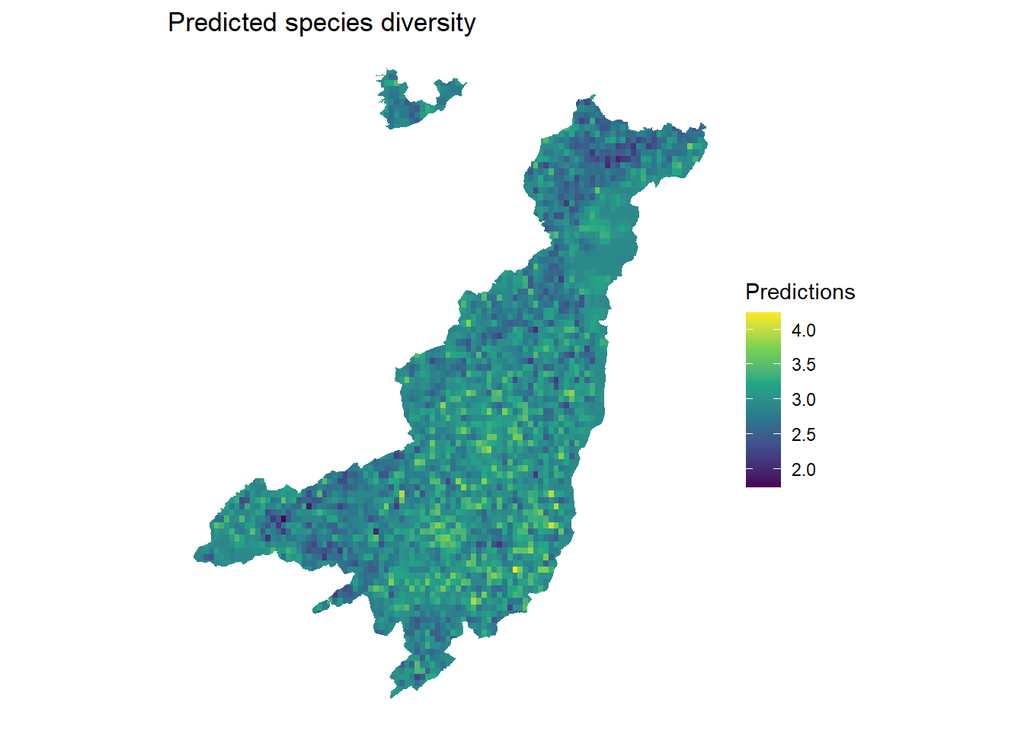

```r
grid_poly <- st_read("grid_poly.gpkg")
grid_xy <- st_read("grid_xy.gpkg")
pred <- predict(m_div, grid_xy, ~ Intercept + matern_field)

pred_grid <- st_drop_geometry(pred)
pred_grid <- st_as_sf(cbind(pred_grid, grid_poly))


ggplot() +
  geom_sf(data = pred_grid, aes(fill = mean), color = NA) +
  scale_fill_continuous(type = "viridis") +
  theme_void() +
  labs(fill = "Predictions",
       title = "Predicted species diversity")
```

#### 4.1.5

Now we want to extend the model to explore the effect of altitude (`zp` in m) on botanical species diversity. Fit this new model, interprete the effect of altitude and compare the fitted spatial fields.